# Homework 1

Anna Bauer, Grant Cai, Alexis Navarra

Winter 2022

```r
algae <- read_table2("algaeBloom.txt", col_names= c('season','size','speed','mxPH','mn02','C1','NO3','NH4','cPO4','PO4','CHla','a1','a2','a3','a4','a5','a6','a7'), na = "XXXXXXX") #assign data to new dataset with column names

glimpse(algae) # view new dataset at a glimpse
```

```
## Rows: 200
## Columns: 18
## $ season <chr> "winter", "spring", "autumn", "spring", "autumn", "winter", "su…
## $ size   <chr> "small", "small", "small", "small", "small", "small", "small", …
## $ speed  <chr> "medium", "medium", "medium", "medium", "medium", "high", "high…
## $ mxPH   <dbl> 8.00, 8.35, 8.10, 8.07, 8.06, 8.25, 8.15, 8.05, 8.70, 7.93, 7.7…
## $ mn02   <dbl> 9.8, 8.0, 11.4, 4.8, 9.0, 13.1, 10.3, 10.6, 3.4, 9.9, 10.2, 11.…
## $ C1     <dbl> 60.80, 57.75, 40.02, 77.36, 55.35, 65.75, 73.25, 59.07, 21.95, …
## $ NO3    <dbl> 6.238, 1.288, 5.330, 2.302, 10.416, 9.248, 1.535, 4.990, 0.886,…
## $ NH4    <dbl> 578.00, 370.00, 346.67, 98.18, 233.70, 430.00, 110.00, 205.67, …
## $ cPO4   <dbl> 105.00, 428.75, 125.67, 61.18, 58.22, 18.25, 61.25, 44.67, 36.3…
## $ PO4    <dbl> 170.00, 558.75, 187.06, 138.70, 97.58, 56.67, 111.75, 77.43, 71…
## $ CHla   <dbl> 50.000, 1.300, 15.600, 1.400, 10.500, 28.400, 3.200, 6.900, 5.5…
## $ a1     <dbl> 0.0, 1.4, 3.3, 3.1, 9.2, 15.1, 2.4, 18.2, 25.4, 17.0, 16.6, 32.…
## $ a2     <dbl> 0.0, 7.6, 53.6, 41.0, 2.9, 14.6, 1.2, 1.6, 5.4, 0.0, 0.0, 0.0, …
## $ a3     <dbl> 0.0, 4.8, 1.9, 18.9, 7.5, 1.4, 3.2, 0.0, 2.5, 0.0, 0.0, 0.0, 2.…
## $ a4     <dbl> 0.0, 1.9, 0.0, 0.0, 0.0, 0.0, 3.9, 0.0, 0.0, 2.9, 0.0, 0.0, 0.0…
## $ a5     <dbl> 34.2, 6.7, 0.0, 1.4, 7.5, 22.5, 5.8, 5.5, 0.0, 0.0, 1.2, 0.0, 1…
## $ a6     <dbl> 8.3, 0.0, 0.0, 0.0, 4.1, 12.6, 6.8, 8.7, 0.0, 0.0, 0.0, 0.0, 0.…
## $ a7     <dbl> 0.0, 2.1, 9.7, 1.4, 1.0, 2.9, 0.0, 0.0, 0.0, 1.7, 6.0, 1.5, 2.1…
```

```r
dim(algae) # get dimensions
```

```
## [1] 200  18
```

1. Descriptive summary statistics (10 pts in total) Given the lack of further information on the problem domain, it is wise to investigate some of the statistical properties of the data, so as to get a better grasp of the problem. It is always a good idea to start our analysis with some kind of exploratory data analysis. A first idea of the statistical properties of the data can be obtained through a summary of its descriptive statistics.
1. Count the number of observations in each size using summarise() in dplyr.

```r
algae %>% # algae dataset
  group_by(size) %>% #group by size
    summarise(n = n())  #summarse function to get # of observations
```

| size | n |
| --- | --- |
| large | 45 |
| medium | 84 |
| small | 71 |

2. Are there missing values? (2 pts) Calculate the mean and variance of each chemical (Ignore a1 through a7). (1 pts) What do you notice about the magnitude of the two quantities for different chemicals?

```r
summary(algae) # get summary
```

```
##     season              size              speed                mxPH
##  Length:200         Length:200         Length:200         Min.   :5.60
##  Class :character   Class :character   Class :character   1st Qu.:7.70
##  Mode  :character   Mode  :character   Mode  :character   Median :8.06
##                                                           Mean   :8.01
##                                                           3rd Qu.:8.40
##                                                           Max.   :9.70
##                                                           NA's   :1
##       mn02             C1             NO3             NH4
##  Min.   : 1.50   Min.   :  0.2   Min.   : 0.05   Min.   :    5
##  1st Qu.: 7.72   1st Qu.: 11.0   1st Qu.: 1.30   1st Qu.:   38
##  Median : 9.80   Median : 32.7   Median : 2.67   Median :  103
##  Mean   : 9.12   Mean   : 43.6   Mean   : 3.28   Mean   :  501
##  3rd Qu.:10.80   3rd Qu.: 57.8   3rd Qu.: 4.45   3rd Qu.:  227
##  Max.   :13.40   Max.   :391.5   Max.   :45.65   Max.   :24064
##  NA's   :2       NA's   :10      NA's   :2       NA's   :2
##       cPO4            PO4             CHla              a1
##  Min.   :  1.0   Min.   :  1.0   Min.   :  0.20   Min.   : 0.00
##  1st Qu.: 15.7   1st Qu.: 41.4   1st Qu.:  2.00   1st Qu.: 1.50
##  Median : 40.1   Median :103.3   Median :  5.47   Median : 6.95
##  Mean   : 73.6   Mean   :137.9   Mean   : 13.97   Mean   :16.92
##  3rd Qu.: 99.3   3rd Qu.:213.8   3rd Qu.: 18.31   3rd Qu.:24.80
##  Max.   :564.6   Max.   :771.6   Max.   :110.46   Max.   :89.80
##  NA's   :2       NA's   :2       NA's   :12
##        a2              a3              a4              a5
##  Min.   : 0.00   Min.   : 0.00   Min.   : 0.00   Min.   : 0.00
##  1st Qu.: 0.00   1st Qu.: 0.00   1st Qu.: 0.00   1st Qu.: 0.00
##  Median : 3.00   Median : 1.55   Median : 0.00   Median : 1.90
##  Mean   : 7.46   Mean   : 4.31   Mean   : 1.99   Mean   : 5.06
##  3rd Qu.:11.38   3rd Qu.: 4.92   3rd Qu.: 2.40   3rd Qu.: 7.50
##  Max.   :72.60   Max.   :42.80   Max.   :44.60   Max.   :44.40
##
##        a6              a7
##  Min.   : 0.00   Min.   : 0.0
##  1st Qu.: 0.00   1st Qu.: 0.0
##  Median : 0.00   Median : 1.0
##  Mean   : 5.96   Mean   : 2.5
##  3rd Qu.: 6.92   3rd Qu.: 2.4
##  Max.   :77.60   Max.   :31.6
##
```

From the summary table above, we can see the number of missing values in each column. The below code chunk calculates the mean and the variance while accounting for the missing values in each of the chemical columns.

```r
mean_col <- cbind(
  lapply(algae[4:11], FUN = mean, na.rm = T) # use lapply
) # define function for the mean of each column in algae
var_col <- cbind(
  lapply(algae[4:11], FUN = var, na.rm = T) # use lapply
) # define function for the variance of each column in algae

knitr::kable(list(mean_col)) # display list
```

| mxPH | 8.01173366834171 |
| --- | --- |
| mn02 | 9.11777777777778 |
| C1 | 43.6362788421053 |
| NO3 | 3.28238888888889 |
| NH4 | 501.295828383838 |
| cPO4 | 73.590595959596 |
| PO4 | 137.882100959596 |
| CHla | 13.9711968085106 |

```r
knitr::kable(list(var_col)) # display list
```

| mxPH | 0.357969327699102 |
| --- | --- |
| mn02 | 5.71808945290468 |
| C1 | 2193.17172527517 |
| NO3 | 14.2617564622109 |
| NH4 | 3851584.68486516 |
| cPO4 | 8305.84993021472 |
| PO4 | 16639.3845452802 |
| CHla | 420.082734939669 |

We notice when making this calculation that some of the variance values are abnormally large (in particular, for chemicals C1, NH4, cPO4, and PO4). This indicates a large spread in the data points for these chemcials.

3. Mean and Variance is one measure of central tendency and spread of data. Median and Median Absolute Deviation are alternative measures of central tendency and spread. For a univariate data set X1,X2, …,Xn, the Median Absolute Deviation (MAD) is defined as the median of the absolute deviations from the data’s median:
   $$MAD = median(|X_i ≠ median(X)|)$$
   (3 pts) Compute median and MAD of each chemical and compare the two sets of quantities (i.e., mean & variance vs. median & MAD). (1 pts) What do you notice?

```r
median_col <- cbind(
  lapply(algae[4:11], FUN = median, na.rm = T) # use lapply
) #define function for median of each column in algae
mad_col <- cbind(
  lapply(algae[4:11], FUN = mad, na.rm = T)
) # define function for mean absolute deviation of each column

knitr::kable(list(median_col)) # list medians
```

| mxPH | 8.06 |
| --- | --- |
| mn02 | 9.8 |
| C1 | 32.73 |
| NO3 | 2.675 |
| NH4 | 103.1665 |
| cPO4 | 40.15 |
| PO4 | 103.2855 |
| CHla | 5.475 |

```r
knitr::kable(list(mad_col)) # list MADs
```

| mxPH | 0.504084 |
| --- | --- |
| mn02 | 2.053401 |
| C1 | 33.2495289 |
| NO3 | 2.172009 |
| NH4 | 111.617548413 |
| cPO4 | 44.0458221 |
| PO4 | 122.3211717 |
| CHla | 6.6717 |

The above code chunk calculates the median and MAD values of each chemical. We notice from these two calculations that overall, they are relatively close to one another. This indicates that in general, there are not very large deviations from the median. However, we noticed that the MAD of mxPH and mn02 both deviated a bit from the median.

2. Data visualization (8 pts in total) Most of the time, the information in the data set is also well captured graphically. Histogram, scatter plot, boxplot, Q-Q plot are frequently used tools for data visualization. Use ggplot for all of these visualizations.
1. (2 pts) Produce a histogram of mnO2 with the title ‘Histogram of mnO2’ based on algae data set. (1 pts) Use an appropriate argument to show the probability instead of the frequency as the vertical axis. (Hint: look at the examples in the help file for function geom_histogram()). (1 pts) Is the distribution skewed?

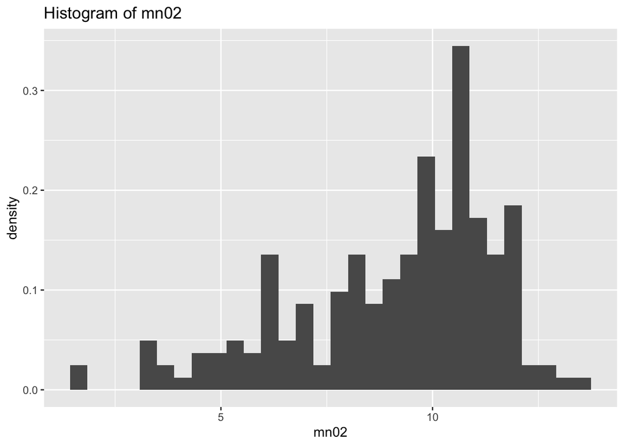

```r
algae1 <- algae %>%
  ggplot(aes(mn02, y = after_stat(density))) +  #include probability instead of count
  ggtitle("Histogram of mn02") + # include title
  geom_histogram(aes(mn02)) # define new object using ggplot to make a histogram


algae1 # print histogram
```

The distribution is left skewed.

2. (1 pts) Add a density curve using geom_density() and (1 pts) rug plots using geom_rug() to above histogram.

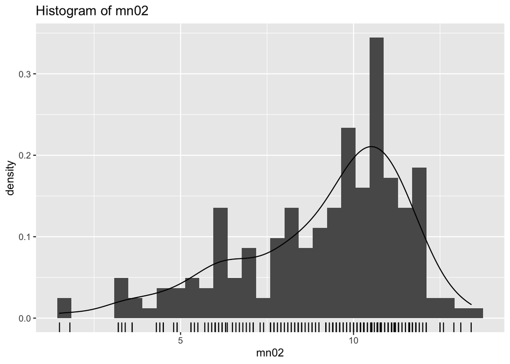

```r
ggplot(data=algae) +  #use ggplot for the histogram with algae data
geom_histogram(aes(mn02, y = after_stat(density))) + #add histogram with density
ggtitle("Histogram of mn02") + # include title
geom_density(aes(mn02, y = after_stat(density))) + # add density curve
geom_rug(aes(mn02)) # add rug plot
```

3. (1 pts) Create a boxplot with the title ‘A conditioned Boxplot of Algal a3’ for a3 grouped by speed. (Refer to help page for geom_boxplot()). (1 pts) What do you notice?

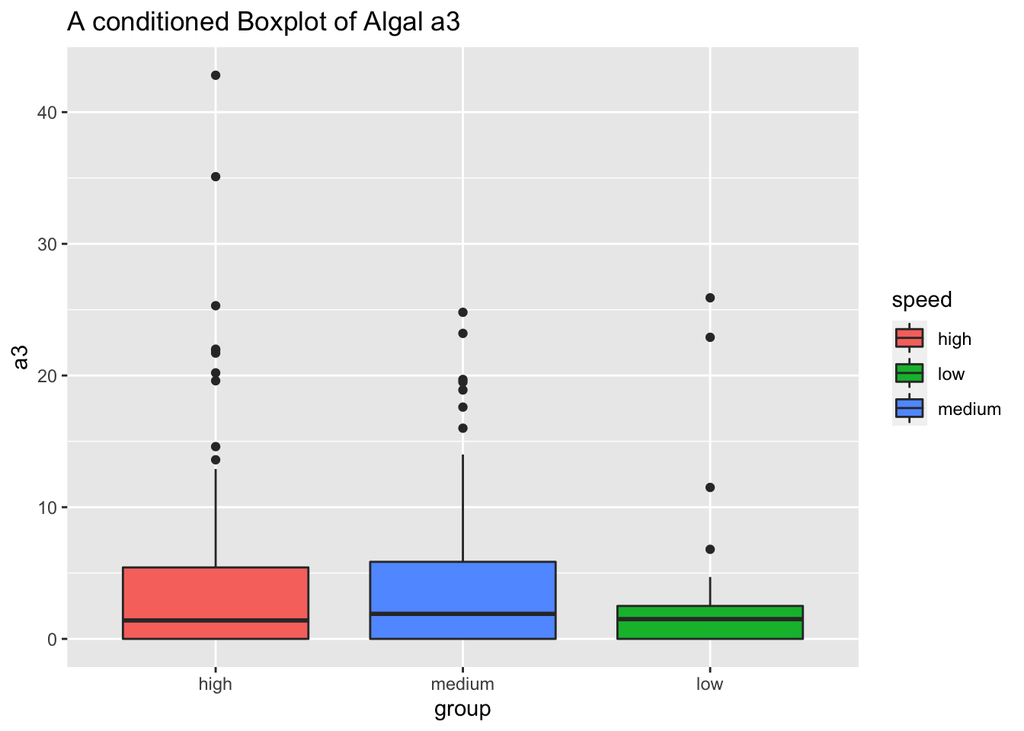

```r
algae_new <- algae # Duplicate data
algae_new$group <- factor(algae_new$speed,
                         c("high", "medium", "low"))   # Reorder factor levels to be in order

algae3 <- ggplot(algae_new, aes(y=a3, fill= speed, group)) +  # use ggplot with a3
  ggtitle("A conditioned Boxplot of Algal a3") + #make title
  geom_boxplot() # make boxplot

algae3 # display
```

We notice that there are multiple outliers, especially in the high speed group. Additionally, the range between the third quantile and the outliers is much larger than the range between the 1st and 3rd quantiles themselves. It appears that the median a3 values are fairly close together for each speed. The interquantile range is much smaller for low speed than medium speed.

3. Dealing with missing values (8 pts in total)
1. (2 pts) How many observations contain missing values? (2 pts) How many missing values are there in each variable?

```r
# Counting how many rows contain missing values
sum(apply(algae, MARGIN = 1, anyNA))
```

```
## [1] 16
```

```r
#Counting NA values for each variable/column
apply(is.na(algae), MARGIN = 2, sum)
```

```
## season   size  speed   mxPH   mn02     C1    NO3    NH4   cPO4    PO4   CHla
##      0      0      0      1      2     10      2      2      2      2     12
##     a1     a2     a3     a4     a5     a6     a7
##      0      0      0      0      0      0      0
```

2. (3 pts) Removing observations with missing values: use filter() function in dplyr package to observations with any missing value, and save the resulting dataset (without missing values) as algae.del. (1 pts) Report how many observations are in algae.del.

```r
algae.del <- algae %>% filter(complete.cases(.)) # remove observations using filter
nrow(algae.del) # record number of rows with missing values removed
```

```
## [1] 184
```

4. In lecture we present the bias-variance tradeoff that takes the form
   $$\mathbb{E}(y_0-\hat{f}(x_0))^2 = \text{Var}(\hat{f}(x_0))+[\text{Bias}(\hat{f}(x_0))]^2+\text{Var}(\epsilon)$$
   where the underlying model $Y = f(X) + \epsilon$ satisifes: (1) $\epsilon$ is a zero-mean random noise, and X is non-random (all randomness in Y comes from $\epsilon$); (2) $(x_0, y_0)$ is a test observation, independent of the training set, and drawn from the same model; (3) $\hat{f}(\cdot)$ is the estimate of f obtained on a training set.
1. (2 pts) Which of the term(s) in the bias-variance tradeoff above represent the reducible error? (2 pts) Which term(s) represent the irreducible error?

$\text{Var}(\hat{f}(x_0))+[\text{Bias}(\hat{f}(x_0))]^2$ is the reducible error. $Var(\epsilon)$ represents the irreducible error.

2. (4 pts) Use the bias-variance tradeoff above to show that the expected test error is always at least as large as the irreducible error.

$\text{Var}(\hat{f}(x_0))$, being the expected value of a squared value, is always non-negative, and the square of $\text{Bias}(\hat{f}(x_0))$ is always positive because it is the square of a value. As a result, the expected test MSE is always at least as large as the irreducible error, $\text{Var}(\epsilon)$.